# Problem 1

Problem 1:

1. Build the best decision tree you can and explain what makes it the best. Show what criteria you used including the number of cases allowed in parents and children and the depth and stopping conditions.

While building the “best” decision tree, I shuffled the data because I didn’t want my training and test sets to be heavily weighted and lopsided of a particular class because this would lead to poor and predictions. Next I split the data into training and test sets using an 80/20 split. This means 80 percent of the data serves as training model and 20 percent of the data in the test set to make predictions.

```r
### install the following packages

#install.packages("e1071")
#install.packages("rpart")
#install.packages("rpart.plot")
#install.packages("ggplot2")
#install.packages("caret")

# load packages
library(e1071)
library(rpart)
library(rpart.plot)
library(ggplot2)
library(caret)
# load data

lupus_data <- read.table("sledata.txt", header = FALSE)

# setting the seed so we get the same results each time we run a decision tree
set.seed(569)
```

Shuffle dataset

```r
# need to shuffle the dataset because when I split the data between the training and test sets, you will select only the select from class 1 and 2, which means the algorithm will never see the features of the other symptoms. If not this will lead to poor predictions. To over come this issue, I will need to use function sample()

shuffle_index <- sample(1:nrow(lupus_data))
head(shuffle_index)
```

```
## [1]   1 176  77  91  26 270
```

```r
# will use this index to suffle the lupus dataset
lupus_data <- lupus_data[shuffle_index, ]
head(lupus_data)
```

```
##     V1 V2 V3 V4 V5 V6 V7 V8 V9 V10 V11 V12
## 1    0  0  0  0  0  0  0  0  0   0   0   1
## 176  1  0  1  0  1  1  1  1  1   1   1   2
## 77   0  0  0  0  1  0  0  0  0   0   0   1
## 91   0  0  0  0  0  0  0  0  0   0   1   1
## 26   0  0  0  0  0  0  0  0  0   0   1   1
## 270  0  0  1  0  0  0  0  1  1   1   1   2
```

Splitting the data 80/20 and looking at the dimensions for train and test set as well looking at the prop.table() function to verify the randomization process was correct.

```r
smp_size <- floor(0.80 * nrow(lupus_data))
train_ind <- sample(seq_len(nrow(lupus_data)), size = smp_size)

train <- lupus_data[train_ind, ]
test  <- lupus_data[-train_ind, ]

# look at the dimensions for the train and test set
dim(train)
```

```
## [1] 240  12
```

```r
dim(test)
```

```
## [1] 60 12
```

```r
# checking randomization process was correct

prop.table(table(train$V12))
```

```
##
##   1   2
## 0.5 0.5
```

```r
prop.table(table(test$V12))
```

```
##
##   1   2
## 0.5 0.5
```

Let’s build a model, I used the rpart program in RStudio to build my classification model. In the rpart program, there are several impurity measures for node diversity.

```r
fit <- rpart(V12~., data = train, method = "class", control = rpart.control(cp = .04))
summary(fit)
```

```
## Call:
## rpart(formula = V12 ~ ., data = train, method = "class", control = rpart.control(cp = 0.04))
##   n= 240
##
##           CP nsplit rel error    xerror       xstd
## 1 0.80833333      0 1.0000000 1.1500000 0.06381941
## 2 0.05833333      1 0.1916667 0.1916667 0.03800204
## 3 0.04000000      2 0.1333333 0.1666667 0.03568120
##
## Variable importance
## V10 V11  V1  V7  V9  V3
##  34  17  14  13  13  10
##
## Node number 1: 240 observations,    complexity param=0.8083333
##   predicted class=1  expected loss=0.5  P(node) =1
##     class counts:   120   120
##    probabilities: 0.500 0.500
##   left son=2 (127 obs) right son=3 (113 obs)
##   Primary splits:
##       V10 < 0.5 to the left,  improve=78.67605, (0 missing)
##       V11 < 0.5 to the left,  improve=46.62857, (0 missing)
##       V9  < 0.5 to the left,  improve=38.72000, (0 missing)
##       V1  < 0.5 to the left,  improve=36.03831, (0 missing)
##       V7  < 0.5 to the left,  improve=31.94682, (0 missing)
##   Surrogate splits:
##       V1  < 0.5 to the left,  agree=0.717, adj=0.398, (0 split)
##       V7  < 0.5 to the left,  agree=0.704, adj=0.372, (0 split)
##       V9  < 0.5 to the left,  agree=0.704, adj=0.372, (0 split)
##       V11 < 0.5 to the left,  agree=0.688, adj=0.336, (0 split)
##       V3  < 0.5 to the left,  agree=0.671, adj=0.301, (0 split)
##
## Node number 2: 127 observations
##   predicted class=1  expected loss=0.1181102  P(node) =0.5291667
##     class counts:   112    15
##    probabilities: 0.882 0.118
##
## Node number 3: 113 observations,    complexity param=0.05833333
##   predicted class=2  expected loss=0.07079646  P(node) =0.4708333
##     class counts:     8   105
##    probabilities: 0.071 0.929
##   left son=6 (9 obs) right son=7 (104 obs)
##   Primary splits:
##       V11 < 0.5 to the left,  improve=13.0894800, (0 missing)
##       V1  < 0.5 to the left,  improve= 1.1128710, (0 missing)
##       V9  < 0.5 to the left,  improve= 0.9826661, (0 missing)
##       V3  < 0.5 to the left,  improve= 0.8672566, (0 missing)
##       V7  < 0.5 to the left,  improve= 0.7496466, (0 missing)
##
## Node number 6: 9 observations
##   predicted class=1  expected loss=0.1111111  P(node) =0.0375
##     class counts:     8     1
##    probabilities: 0.889 0.111
##
## Node number 7: 104 observations
##   predicted class=2  expected loss=0  P(node) =0.4333333
##     class counts:     0   104
##    probabilities: 0.000 1.000
```

Let’s make some predictions on the training set and test set. First, lets look at the training set predictions…

```r
predicted <- predict(fit, type = "class")

confusionMatrix(predicted, train$V12)
```

```
## Confusion Matrix and Statistics
##
##           Reference
## Prediction   1   2
##          1 120  16
##          2   0 104
##
##                Accuracy : 0.9333
##                  95% CI : (0.894, 0.9614)
##     No Information Rate : 0.5
##     P-Value [Acc > NIR] : < 2.2e-16
##
##                   Kappa : 0.8667
##  Mcnemar's Test P-Value : 0.0001768
##
##             Sensitivity : 1.0000
##             Specificity : 0.8667
##          Pos Pred Value : 0.8824
##          Neg Pred Value : 1.0000
##              Prevalence : 0.5000
##          Detection Rate : 0.5000
##    Detection Prevalence : 0.5667
##       Balanced Accuracy : 0.9333
##
##        'Positive' Class : 1
##
```

Now for the test set predictions.

```r
newpred <- predict(fit, test, type = "class")
confusionMatrix(newpred, test$V12)
```

```
## Confusion Matrix and Statistics
##
##           Reference
## Prediction  1  2
##          1 29  3
##          2  1 27
##
##                Accuracy : 0.9333
##                  95% CI : (0.838, 0.9815)
##     No Information Rate : 0.5
##     P-Value [Acc > NIR] : 4.542e-13
##
##                   Kappa : 0.8667
##  Mcnemar's Test P-Value : 0.6171
##
##             Sensitivity : 0.9667
##             Specificity : 0.9000
##          Pos Pred Value : 0.9062
##          Neg Pred Value : 0.9643
##              Prevalence : 0.5000
##          Detection Rate : 0.4833
##    Detection Prevalence : 0.5333
##       Balanced Accuracy : 0.9333
##
##        'Positive' Class : 1
##
```

Observing the prediction results from the training and test sets, there was an accuracy of 0.9333 and 0.9333, respectively. Both sets are pretty well balanced. I would designate this decision tree as the best. There seems to be a balanced split.

2. How many nodes does the final tree have and how many of them are terminal nodes?

Below is the decision tree model, there are three levels of the decision tree. There are a total of four nodes (not including the root the node). There are three terminal nodes, meaning a final decision node.

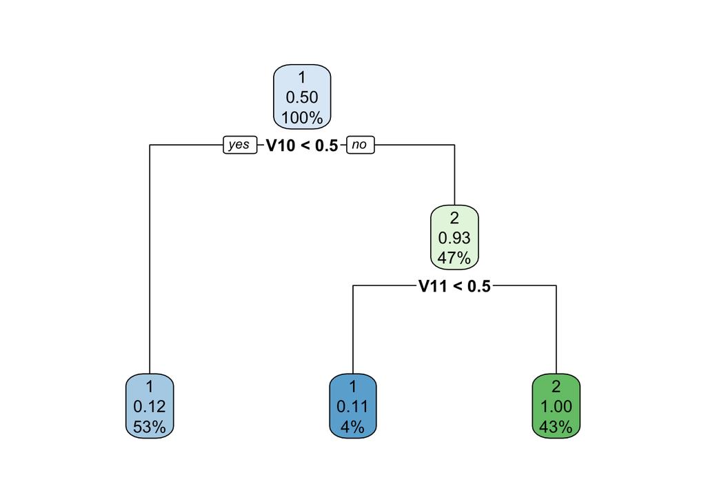

3. What are the most important three Lupus data features in building the tree? Explain your answer. Based on this decision tree model, the most important three Lupus data features are: V10, V11 and V1. These variables are deemed important based on the summation of the goodness of the split measures for each split.
4. Increase the parameters that let you set the number of cases allowed in parent and child nodes. What do you notice with the complexity(number of nodes) of the tree? Explain your answer.

First, I will use the train and test datasets from the lupus_data dataset. I will build a new decision tree changing some parameters. The cp means complexity parameter.

```r
mod_fit <- rpart(V12 ~., method = "class", data = train, control = rpart.control( cp = 0))
summary(mod_fit)
```

```
## Call:
## rpart(formula = V12 ~ ., data = train, method = "class", control = rpart.control(cp = 0))
##   n= 240
##
##           CP nsplit rel error    xerror       xstd
## 1 0.80833333      0 1.0000000 1.1333333 0.06397337
## 2 0.05833333      1 0.1916667 0.1916667 0.03800204
## 3 0.02916667      2 0.1333333 0.1666667 0.03568120
## 4 0.00000000      4 0.0750000 0.1500000 0.03400368
##
## Variable importance
## V10  V9 V11  V7  V1  V3
##  32  16  16  13  13  10
##
## Node number 1: 240 observations,    complexity param=0.8083333
##   predicted class=1  expected loss=0.5  P(node) =1
##     class counts:   120   120
##    probabilities: 0.500 0.500
##   left son=2 (127 obs) right son=3 (113 obs)
##   Primary splits:
##       V10 < 0.5 to the left,  improve=78.67605, (0 missing)
##       V11 < 0.5 to the left,  improve=46.62857, (0 missing)
##       V9  < 0.5 to the left,  improve=38.72000, (0 missing)
##       V1  < 0.5 to the left,  improve=36.03831, (0 missing)
##       V7  < 0.5 to the left,  improve=31.94682, (0 missing)
##   Surrogate splits:
##       V1  < 0.5 to the left,  agree=0.717, adj=0.398, (0 split)
##       V7  < 0.5 to the left,  agree=0.704, adj=0.372, (0 split)
##       V9  < 0.5 to the left,  agree=0.704, adj=0.372, (0 split)
##       V11 < 0.5 to the left,  agree=0.688, adj=0.336, (0 split)
##       V3  < 0.5 to the left,  agree=0.671, adj=0.301, (0 split)
##
## Node number 2: 127 observations,    complexity param=0.02916667
##   predicted class=1  expected loss=0.1181102  P(node) =0.5291667
##     class counts:   112    15
##    probabilities: 0.882 0.118
##   left son=4 (103 obs) right son=5 (24 obs)
##   Primary splits:
##       V9  < 0.5 to the left,  improve=10.617700, (0 missing)
##       V1  < 0.5 to the left,  improve= 6.469232, (0 missing)
```

[output cut: 39 more lines]

```
##
## Node number 7: 104 observations
##   predicted class=2  expected loss=0  P(node) =0.4333333
##     class counts:     0   104
##    probabilities: 0.000 1.000
##
## Node number 10: 17 observations
##   predicted class=1  expected loss=0.3529412  P(node) =0.07083333
##     class counts:    11     6
##    probabilities: 0.647 0.353
##
## Node number 11: 7 observations
##   predicted class=2  expected loss=0  P(node) =0.02916667
##     class counts:     0     7
##    probabilities: 0.000 1.000
```

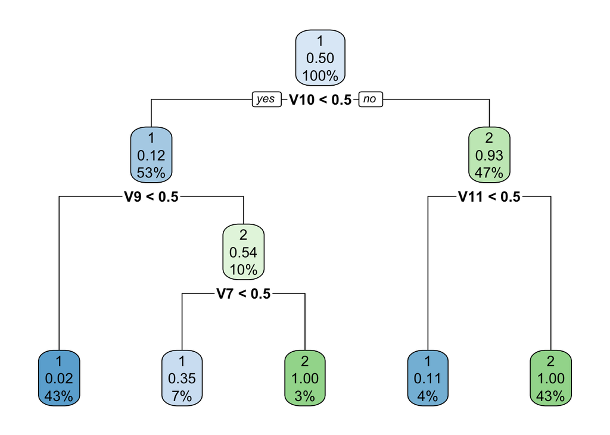